# Multinomial and Ordinal Logistic Regression

Dr Irina Chis Ster

06/03/2021

# OUTLINE

- Multinomial Logistic Regression - what is it and why do we need it?
- Assumptions
- Measures of associations and hypothesis testing
- Goodness of fit
- Model choice
- Predictions
- Ordinal Logistic Regression - what is it and why do we need it?

## Multinomial Logistic Regression

- A(nother) generalized linear model
  - linearity assumption extends from that between the outcome and independent variable (continuous outcome situation) to that between the log of the risk ratios and the potential explanatory variables
- Supervised learning technique - parametric techniques
- A regression technique applicable to nominal outcomes/responses/dependent variables with more than two categories
  - Continuous outcomes - linear and multiple/multivariable regression
  - Binary outcomes - univariate and multivariable/multiple logistic regression
  - Nominal outcomes - multinomial logistic regression
- Outcomes of different statistical types require different regression techniques

## Measures of associations

- The outcome and the explanatory/independent variable(s)
- Continuous outcome - *regression coefficient* (NOT correlation)
- Logistic regression - *odds ratios (OR)*
- Multinomial logistic regression - (*relative) risk ratios (RRR)*

## Hypothesis testing (2-sided)

### Univariate association

- *Continuous outcome - linear regression*
  - H0: no linear association between the outcome and the independent variable which translates into regression coefficient (slope of the regression line) $\beta=0$
  - H1:there is a linear association between the outcome and the independent variable which translates into regression coefficient (slope of the regression line) $\beta\neq 0$
- Binary outcome - Logistic regression
  - H0: no association between the outcome and the independent variable translates into $OR=1$
  - H1: there is an association between outcome and the independent variable which translates translates into $OR\neq 1$
- Nominal data - Multinomial logistic regression
  - H0: no association between outcome and independent variables translates into $RRR=1$
  - H1: there is an association between outcome and the independent variable which translates into $RRR\neq 1$

### Multivariable associations

- Continuous outcomes
  - H0: All regression coefficients are 0
  - H1: At least one is not 0
- Logistic regression -
  - H0: All OR=1
  - H1: At least one OR not 1
- Multinomial logistic regression -
  - H0: All RRR=1
  - H1: At least one RRR is not 1

## Assumptions

- Independence of the observations
- All models assume some kind of linear relationship:
  - Continuous outcome: between the outcome and the independent variables
  - Binary outcome: between the Log(OR) of the outcome and the independent variables
  - Nominal outcomes: between the Log(RR) of the outcome and the independent variables

## Goodness of fit and model diagnosis

- Continuous outcomes only: residuals play a central role in assessing model goodness of fit and diagnosis
- Binary outcomes: no residuals. Hosmer-Lemeshow statistics
- Categorical outcomes: the model is in essence a group of logistic regressions fit all at once to the data
  - Similar results should hold if separate logistic regressions for binary outcomes constructed from the original nominal outcome

## Model choice

As for the all regression techniques:

- Nested models - likelihood ratios comparisons
  - H0: The two models are equally good
  - H1: The two model with the larger number of explanatory variables is a better fit to the data
- Non-nested models - AIC criterion: the smaller the value, the better the model. The AIC has no particular meaning per se.

## Interpretation:

- Continuous outcome: a regression coefficient and its corresponding 95%CI on either side of 0 indicates a statistically significant effect.
- Categorical outcome: an RR (OR) and its corresponding 95%CI on either side of 1 indicates a statistically significant effect.
- The magnitude and the sense of the effect differ according to the independent variable nature (continuous or categorical)

## Reminder:

- Risk: $\pi=\frac{D}{N}$
- Odds: $\frac{\pi}{1-\pi}=\frac{D}{\bar D}$
- Risk Ratios: $\frac{\pi_{women}}{\pi_{men}}$
- Odds Ratios: $\frac{OR_{women}}{OR_{men}}$
- Relative Risk Ratios:$\frac{{\frac{RR_{women}}{RR_{men}}_{UK}}}{{\frac{RR_{women}}{RR_{men}}}_{France}}$

# Example 1: Social science data

- US 1996 National Election Study: 10 variable subset of the 1996 American National Election Study. Missing values and “don’t know” responses have been list wise deleted. Respondents expressing a voting preference other than Clinton or Dole have been removed. (**Source:** Sapiro, Virginia, Steven J. Rosenstone, Donald R. Kinder, Warren E. Miller, and the National Election Studies. AMERICAN NATIONAL ELECTION STUDIES, 1992-1997: Ann Arbor, MI: University of Michigan)
- Variables in the data:
  - **Popul:** population of respondent’s location in 1000s of people
  - **TVnews** days in the past week spent watching news on TV
  - **selfLR:** Left-Right self-placement of respondent: an ordered factor with levels
    - extremely liberal (extLib)
    - liberal (Lib)
    - slightly liberal (sliLib)
    - moderate (Mod)
    - slightly conservative (sliCon)
    - conservative (Con)
    - extremely conservative (extCon)
  - **ClinLR:** Left-Right placement of Bill Clinton (same scale as selfLR): an ordered factor with 7 levels as above
  - **DoleLR:** Left-Right placement of Bob Dole (same scale as selfLR): an ordered factor with 7 levels as above
  - **PID:** Party identification: an ordered factor with levels
    - strong Democrat (strDem)
    - weak Democrat (weakDem)
    - independent Democrat (indDem)
    - independent independent (indind)
    - indepedent Republican (indRep)
    - weak Republican (weakRep)
    - strong Republican (strRep)
  - **age:** Respondent’s age in years
  - **educ:** Respondent’s education: an ordered factor with levels
    - 8 years or less (MS)
    - high school dropout (HSdrop)
    - high school diploma or GED (HS)
    - some College (Coll)
    - Community or junior College degree (CCdeg)
    - BA degree (BAdeg)
    - postgraduate degree (MAdeg)
  - **Income**: Respondent’s family income: an ordered factor with levels from less than 3K to 105Kplus in uneven i.e. (`$3K-$5K`,`$5K-$7K`,`$7K-$9K`,`$9K-$10K`,`$10K-$11K`,`$11K-$12K`,`$12K-$13K`,`$13K-$14K`,`$14K-$15K`,`$15K-$17K`,`$17K-$20K`,`$20K-$22K`,`$22K-$25K`,`$25K-$30K`, `$30K-$35`, `$35K-$40K`, `$40K-$45K`,`$45K-$50K, $50K-$60K`,`$60K-$75K`,`$75K-$90K`, `$90K-$105K`
  - **Vote:** Expected vote in 1996 presidential election: a factor with level Clinton and Dole

## Reading the data

```r
mydata<-read.table("Survey.txt", header=T, sep="\t")
dim(mydata)
```

```
[1] 944  10
```

```r
names(mydata)
```

```
 [1] "popul"  "TVnews" "selfLR" "ClinLR" "DoleLR" "PID"    "age"    "educ"   "income" "vote"
```

## Creating a series of 3-category nominal variables

### The outcome

```r
mydata$PID_factor <- mydata$PID

## R order strings in alphabetical order
table(mydata$PID)
```

```
 indDem  indind  indRep  strDem  strRep weakDem weakRep
    108      37      94     200     175     180     150
```

```r
##create the new factor
levels(mydata$PID_factor) <- c("Independent","Independent", "Independent", "Democrat", "Republican", "Democrat","Republican")

table(mydata$PID_factor,mydata$PID)
```

```
              indDem indind indRep strDem strRep weakDem weakRep
  Independent    108     37     94      0      0       0       0
  Democrat         0      0      0    200      0     180       0
  Republican       0      0      0      0    175       0     150
```

### The education level

```r
mydata$educ_factor<-mydata$educ
table(mydata$educ)
levels(mydata$educ_factor) <- c("High","Average", "Average", "Average", "Low", "High","Low")
table(mydata$educ,mydata$educ_factor)
```

### The income level

```r
##this is a string which R orders in alphabetical order
table(mydata$income)

mydata$income_factor<-mydata$income
table(mydata$income_factor)
levels(mydata$income_factor) <- c("130", "5","7", "9", "10", "11", "12","13","14","15", "17", "20", "22", "25","3","30", "35", "40", "45","50","60", "75", "90", "105")
table(mydata$income_factor, mydata$income)

mydata$income_numeric<-as.numeric(mydata$income_factor)
is.numeric(mydata$income_numeric)
```

## The multinomial logistic - univariate model

### Continuous independent variable - summary at the log scale

```r
multinom_on_age <- multinom(mydata$PID_factor ~ age, data =mydata)
summary(multinom_on_age)
```

[output not shown]

### Continuous independent variable - summary transformed for RR interpretation

```r
multinom_on_age_test <- summary(multinom_on_age)$coefficients/summary(multinom_on_age)$standard.errors

# 2-tailed z test
multinom_on_age_p <- (1 - pnorm(abs(multinom_on_age_test), 0, 1)) * 2
multinom_on_age_p
```

```
           (Intercept)      age
Democrat     0.1440020 0.678746
Republican   0.5645947 0.517129
```

```r
exp(coef(multinom_on_age))
```

```
           (Intercept)      age
Democrat      1.441530 1.002097
Republican    1.160629 1.003379
```

```r
exp(confint(multinom_on_age))
```

```
, , Democrat

                2.5 %   97.5 %
(Intercept) 0.8826029 2.354409
age         0.9922124 1.012080

, , Republican

                2.5 %   97.5 %
(Intercept) 0.6991528 1.926702
age         0.9931901 1.013672
```

### Interpretation:

1.002= The relative risk ratio for a one year increase in **age** for being Democrat relative to Independent. For one year increase in age, the relative risk (probability) for being a Democrat relative to Independent would be expected to increase by a factor of 1.002. The p-value is 0.679 - so this is not statistically significant.

## The multinomial univariate model

### Categorical independent variable - summary at the log scale

```r
multinom_on_edu <- multinom(mydata$PID_factor ~ educ_factor, data =mydata)
summary(multinom_on_edu)
```

[output not shown]

Interpretation for estimates at log scale:

- The baseline of the outcome factor is “independent”.
- The baseline for education factor is “high”.
- There are 4 relative relationships:
  - RR of Democrat vs. Independent for Average vs. High education
  - RR of Democrat vs. Independent for Low vs. High education
  - RR of Republic vs. Independent for Average vs. High education
  - RR of Republic vs. Independent for Low vs. High education

```r
# 2-tailed z test
multinom_on_edu_test <- summary(multinom_on_edu)$coefficients/summary(multinom_on_edu)$standard.errors

multinom_on_edu_p <- (1 - pnorm(abs(multinom_on_edu_test), 0, 1)) * 2
multinom_on_edu_p
```

```
           (Intercept) educ_factorAverage educ_factorLow
Democrat    0.03767291          0.1576049     0.10487928
Republican  0.01225168          0.8952172     0.03922446
```

- The p-values correspond to
  - RR of Democrat vs. Independent for Average vs. High education (p=0.157)
  - RR of Democrat vs. Independent for Low vs. High education (p=0.105)
  - RR of Republic vs. Independent for Average vs. High education (p=0.895)
  - RR of Republic vs. Independent for Low vs. High education (p=0.039)

### Categorical independent variable - summary transformed for RR interpretation

```r
exp(coef(multinom_on_edu))
```

```
           (Intercept) educ_factorAverage educ_factorLow
Democrat      1.326320           1.282332      1.6853331
Republican    1.400006           1.023618      0.4201607
```

- There are 4 relative relationships:
  - RR of Democrat vs. Independent is 1.28 higher for Average compared to High education
  - RR of Democrat vs. Independent is 1.69 higher for Low compared to High education
  - RR of Republican vs. Independent is 1.02 higher for Average compared to High education
  - RR of Republican vs. Independent is 0.42 of Low compared to High education

```r
exp(confint(multinom_on_edu))
```

```
, , Democrat

                       2.5 %   97.5 %
(Intercept)        1.0162225 1.731044
educ_factorAverage 0.9082637 1.810460
educ_factorLow     0.8968242 3.167118

, , Republican

                       2.5 %    97.5 %
(Intercept)        1.0759355 1.8216869
educ_factorAverage 0.7232224 1.4487850
educ_factorLow     0.1842618 0.9580663
```

- There are 4 relative 95%CI:
  - RR of Democrat vs. Independent is 1.28 higher for Average compared to High education (0.91-1.81)
  - RR of Democrat vs. Independent is 1.69 higher for Low compared to High education (0.897-3.167)
  - RR of Republican vs. Independent is 1.02 higher for Average compared to High education (0.723 - 1.449)
  - RR of Republican vs. Independent is 0.42 for Low compared to High education (0.184-0.958)

## The multinomial mutiple/multivariable model

### ADDITIVE MODEL

```r
multinom_on_additive <- multinom(mydata$PID_factor ~ income_numeric+ educ_factor, data =mydata)
summary(multinom_on_additive)
```

```
Call:
multinom(formula = mydata$PID_factor ~ income_numeric + educ_factor,
    data = mydata)

Coefficients:
           (Intercept) income_numeric educ_factorAverage educ_factorLow
Democrat     0.5440052   -0.018717139         0.24625740      0.4818692
Republican   0.2787620    0.003966707         0.02461765     -0.8581089

Std. Errors:
           (Intercept) income_numeric educ_factorAverage educ_factorLow
Democrat     0.2278867     0.01299326          0.1762007      0.3234498
Republican   0.2380939     0.01352571          0.1772987      0.4216770

Residual Deviance: 2020.158
AIC: 2036.158
```

- Interpretation -estimates at log scale
- Same as above - but controlled/adjusted for income
- In addition:
  - RR of Democrat vs. Independent decreases with increasing income - controlled for education level
  - RR of Republican vs. Independent increases with increasing income - controlled for education level

```r
multinom_on_additive_test <- summary(multinom_on_additive)$coefficients/summary(multinom_on_additive)$standard.errors

# 2-tailed z test
multinom_on_additive_p <- (1 - pnorm(abs(multinom_on_additive_test), 0, 1)) * 2
multinom_on_additive_p
```

```
           (Intercept) income_numeric educ_factorAverage educ_factorLow
Democrat    0.01697843      0.1497186          0.1622343     0.13628201
Republican  0.24167647      0.7693146          0.8895699     0.04185179
```

```r
exp(coef(multinom_on_additive))
```

```
           (Intercept) income_numeric educ_factorAverage educ_factorLow
Democrat      1.722894      0.9814569           1.279229      1.6190980
Republican    1.321493      1.0039746           1.024923      0.4239631
```

```r
exp(confint(multinom_on_additive))
```

```
, , Democrat

                       2.5 %   97.5 %
(Intercept)        1.1022523 2.692997
income_numeric     0.9567784 1.006772
educ_factorAverage 0.9056616 1.806885
educ_factorLow     0.8589188 3.052068

, , Republican

                       2.5 %    97.5 %
(Intercept)        0.8287029 2.1073211
income_numeric     0.9777090 1.0309458
educ_factorAverage 0.7240597 1.4508024
educ_factorLow     0.1855222 0.9688581
```

## The multinomial mutiple/multivariable model

### INTERACTION MODEL

Are the effects of education on the RR of Democrat/Republican vs. Independent modified by the income level? Or, the other way around, is the effect of income level on the RR of Democrat/Republican vs. Independent modified by the education level?

Fitting the model

```r
multinom_on_multiplic <- multinom(mydata$PID_factor ~ income_numeric* educ_factor, data =mydata)
summary(multinom_on_multiplic)
```

```
Call:
multinom(formula = mydata$PID_factor ~ income_numeric * educ_factor,
    data = mydata)

Coefficients:
           (Intercept) income_numeric educ_factorAverage educ_factorLow income_numeric:educ_factorAverage income_numeric:educ_factorLow
Democrat     0.2051117    0.005681104          1.0055395      0.7113583                       -0.05353871                   -0.01540540
Republican  -0.1391581    0.033255767          0.9834908     -1.0153965                       -0.06681377                    0.01592713

Std. Errors:
           (Intercept) income_numeric educ_factorAverage educ_factorLow income_numeric:educ_factorAverage income_numeric:educ_factorLow
Democrat     0.2874351     0.01864526          0.4205534      0.6867680                        0.02718976                    0.05107887
Republican   0.3030413     0.01908461          0.4402567      0.9545572                        0.02797037                    0.06561666

Residual Deviance: 2013.359
AIC: 2037.359
```

The p-values

```r
# 2-tailed z test
multinom_on_multiplic_test <- summary(multinom_on_multiplic)$coefficients/summary(multinom_on_multiplic)$standard.errors

multinom_on_multiplic_p <- (1 - pnorm(abs(multinom_on_multiplic_test), 0, 1)) * 2
multinom_on_multiplic_p
```

```
           (Intercept) income_numeric educ_factorAverage educ_factorLow income_numeric:educ_factorAverage income_numeric:educ_factorLow
Democrat     0.4754788     0.76059895         0.01680295      0.3002927                        0.04894438                     0.7629568
Republican   0.6460869     0.08141334         0.02548944      0.2874485                        0.01690655                     0.8082146
```

The RR

```r
exp(coef(multinom_on_multiplic))
```

```
           (Intercept) income_numeric educ_factorAverage educ_factorLow income_numeric:educ_factorAverage income_numeric:educ_factorLow
Democrat     1.2276622       1.005697           2.733382      2.0367559                         0.9478693                     0.9847127
Republican   0.8700904       1.033815           2.673774      0.3622588                         0.9353694                     1.0160546
```

```r
exp(confint(multinom_on_multiplic))
```

```
, , Democrat

                                      2.5 %    97.5 %
(Intercept)                       0.6988978 2.1564735
income_numeric                    0.9696085 1.0431293
educ_factorAverage                1.1987388 6.2326960
educ_factorLow                    0.5301039 7.8255878
income_numeric:educ_factorAverage 0.8986787 0.9997523
income_numeric:educ_factorLow     0.8909044 1.0883985

, , Republican

                                       2.5 %    97.5 %
(Intercept)                       0.48041347 1.5758455
income_numeric                    0.99585922 1.0732173
educ_factorAverage                1.12817761 6.3368261
educ_factorLow                    0.05578254 2.3525535
income_numeric:educ_factorAverage 0.88547178 0.9880788
income_numeric:educ_factorLow     0.89343726 1.1555003
```

#### Goodness of fit

```r
logitgof(mydata$PID_factor, fitted(multinom_on_multiplic)  )
```

```
    Hosmer and Lemeshow test (multinomial model)

data:  mydata$PID_factor, fitted(multinom_on_multiplic)
X-squared = 11.7, df = 16, p-value = 0.7644
```

#### Model choice

```r
lrtest(multinom_on_multiplic, multinom_on_additive)
```

```
Likelihood ratio test

Model 1: mydata$PID_factor ~ income_numeric * educ_factor
Model 2: mydata$PID_factor ~ income_numeric + educ_factor
  #Df  LogLik Df  Chisq Pr(>Chisq)
1  12 -1006.7
2   8 -1010.1 -4 6.7985     0.1469
```

```r
AIC(multinom_on_multiplic, multinom_on_additive)
```

|  | df | AIC |
| --- | --- | --- |
| multinom_on_multiplic | 12 | 2037.359 |
| multinom_on_additive | 8 | 2036.158 |

### PREDICTIONS

#### Create a speadsheet of values within the data range

##### Predictions by education factor at the means of income levels

```r
create_data_pred <- data.frame(educ_factor = c("Low", "Average", "High"), income_numeric = mean(mydata$income_numeric))
predict(multinom_on_multiplic, newdata = create_data_pred, "probs")
```

```
  Independent  Democrat Republican
1   0.2625622 0.5735930  0.1638447
2   0.2388750 0.4124066  0.3487184
3   0.2695982 0.3581443  0.3722575
```

*Interpretation:* these are the absolute proportions (risk) of being across each education level and for independent/democrat/republican at the average income. The proportions add to 1 across every row (education level).

##### Predictions by education factor at detailed by income levels

```r
create_data_pred_2 <- data.frame(educ_factor = rep(c("Low", "Average", "High"), each = 128), income_numeric = rep(c(3:130),1))

## store the predicted probabilities for each value of education and income
pp.income <- cbind(create_data_pred_2, predict(multinom_on_multiplic, newdata =create_data_pred_2, type = "probs", se = TRUE))

## calculate the mean probabilities within each level of education
by(pp.income[, 3:5], pp.income$income_numeric, colMeans)
```

```r
## melt data set to long for ggplot2
lpp <- melt(pp.income, id.vars = c("educ_factor", "income_numeric"), value.name="probability")
head(lpp)  # view first few rows
```

|  | educ_factor | income_numeric | variable | value |
| --- | --- | --- | --- | --- |
| 1 | Low | 3 | Independent | 0.2635832 |
| 2 | Low | 4 | Independent | 0.2639370 |
| 3 | Low | 5 | Independent | 0.2642111 |
| 4 | Low | 6 | Independent | 0.2644017 |
| 5 | Low | 7 | Independent | 0.2645053 |
| 6 | Low | 8 | Independent | 0.2645182 |

```r
## plot predicted probabilities across income values for each level of education

ggplot(lpp, aes(x = income_numeric, y = value, colour = educ_factor)) + geom_line() + facet_grid(variable ~., scales = "free")
```

[output not shown]

# Ordinal logistic regression

- Applied to an ordinal dependent (response) variables
- The independent variables may be categorical factors or continuous covariates.
- One of the assumptions underlying ordered logistic regression is that the relationship between each pair of outcome groups is the same.
- In other words, ordered logistic regression assumes that the coefficients that describe the relationship between, say, the lowest versus all higher categories of the response variable are the same as those that describe the relationship between the next lowest category and all higher categories, etc.
- This is called the *proportional odds assumption or the parallel regression assumption*. This can be checked by *Brant test* in R:
  - H0: the proportional odds assumption holds
  - H1: the proportional odds assumption does not hold
- If *Brant test* indicates that the parallel regression assumption is violated, we would need different models to describe the relationship between each pair of outcome groups.
- A midway between regression on continuous outcomes and nominal outcomes
- Model choice - similar in all regression techniques.

# Example 2: Social science

- Cross sectional study in a population of young college attendants asked how likely is that they would apply to study for further university degrees
- *Outcome/Dependent/Response variable:* a three level variable called **apply** with levels “unlikely”, “somewhat likely”, and “very likely”, coded 1, 2, and 3, respectively.
- Three *independent variables*::
  - **pared**: a binary 0/1 variable indicating whether at least one parent has a graduate degree;
  - **public**: a binary 0/1 variable indicating that the undergraduate institution is public (1) and (0) private, and
  - **gpa**: which is the student’s grade point average - continuous

## Reading and exploring the data

```r
mydata<-read.table("OrdinalLogisticExample.txt", header=T, sep="\t")
mydata
names(mydata)

##this is an ordinal outcome as we cannot mathematically operate in any way

## one at a time, table apply, pared, and public
lapply(mydata[, c("apply", "pared", "public")], table)
## three way cross tabs (xtabs) and flatten the table
ftable(xtabs(~ public + apply + pared, data = mydata))
summary(mydata$gpa)
sd(mydata$gpa)

##explores the outcome by the three independent variables
##We can also examine the distribution of gpa at every level of applyand broken down by public and pared. This creates a 2 x 2 grid with a boxplot of gpa for every level of apply, ##for particular values of pared and public.

##To better see the data, we also add the raw data points on top of the box plots, with a small amount of noise (often called "jitter") and 50% transparency so they do not overwhelm the boxplots.

##Finally, in addition to the cells, we plot all of the marginal relationships. The margins make the final plot a 3 x 3 grid. In the lower right hand corner, is the overall relationship between apply and gpa.

ggplot(mydata, aes(x = apply, y = gpa)) +
  geom_boxplot(size = .75) +
  geom_jitter(alpha = .5) +
  facet_grid(pared ~ public, margins = TRUE) +
  theme(axis.text.x = element_text(angle = 45, hjust = 1, vjust = 1))
```

## Creating an ordinal outcome

```r
mydata$apply_factor<-as.factor(mydata$apply_cat)
table(mydata$apply_factor,mydata$apply)
```

## Fitting a multivariable ordinal logistic regression

```r
## fit ordered logit model and store results 'model1'
model1 <- polr(apply_factor ~ public* gpa+ pared  , data = mydata, Hess=TRUE)

## view a summary of the model
summary(model1)
```

```
Call:
polr(formula = apply_factor ~ public * gpa + pared, data = mydata,
    Hess = TRUE)

Coefficients:
             Value Std. Error t value
public     -1.6539     2.4772 -0.6676
gpa         0.5489     0.2795  1.9639
pared       1.0448     0.2659  3.9287
public:gpa  0.4960     0.7628  0.6502

Intercepts:
    Value   Std. Error t value
1|2  2.0032  0.8355     2.3978
2|3  4.1008  0.8574     4.7831

Residual Deviance: 716.5953
AIC: 728.5953
```

## The associated p-values

```r
(ctable <- coef(summary(model1)))
```

```
                Value Std. Error    t value
public     -1.6539098  2.4772273 -0.6676455
gpa         0.5488953  0.2794864  1.9639430
pared       1.0448229  0.2659449  3.9287198
public:gpa  0.4959752  0.7628093  0.6501955
1|2         2.0032459  0.8354610  2.3977730
2|3         4.1008081  0.8573550  4.7830924
```

```r
## calculate and store p values
p <- pnorm(abs(ctable[, "t value"]), lower.tail = FALSE) * 2

## combined table
(ctable <- cbind(ctable, "p value" = p))
```

```
                Value Std. Error    t value      p value
public     -1.6539098  2.4772273 -0.6676455 5.043599e-01
gpa         0.5488953  0.2794864  1.9639430 4.953671e-02
pared       1.0448229  0.2659449  3.9287198 8.539926e-05
public:gpa  0.4959752  0.7628093  0.6501955 5.155659e-01
1|2         2.0032459  0.8354610  2.3977730 1.649508e-02
2|3         4.1008081  0.8573550  4.7830924 1.726187e-06
```

## The ODDS RATIOS

```r
## ci
(ci <- confint(model1)) # default method gives profiled CIs
```

```
                  2.5 %   97.5 %
public     -6.702390073 3.083515
gpa         0.003674263 1.101267
pared       0.524976607 1.569590
public:gpa -0.971188643 2.038965
```

```r
## odds ratios
exp(coef(model1))
```

```
    public        gpa      pared public:gpa
 0.1913005  1.7313393  2.8428949  1.6420988
```

```r
## OR and CI
exp(cbind(OR = coef(model1), ci))
```

```
                  OR       2.5 %    97.5 %
public     0.1913005 0.001227973 21.835021
gpa        1.7313393 1.003681021  3.007976
pared      2.8428949 1.690419305  4.804679
public:gpa 1.6420988 0.378632711  7.682652
```

## Interpretation for the additive models

```r
## only brant model is validated as proportional assumptions
brant(model1)
```

```
--------------------------------------------
Test for    X2  df  probability
--------------------------------------------
Omnibus     6.32    4   0.18
public      2.26    1   0.13
gpa     0.67    1   0.41
pared       0.1 1   0.75
public:gpa  1.58    1   0.21
--------------------------------------------

H0: Parallel Regression Assumption holds
```

There is no evidence to suggest that the model does violate the parallel assumption.

```r
newdat <- data.frame(
  pared = rep(0:1, 200),
  public = rep(0:1, each = 200),
  gpa = rep(seq(from = 1.9, to = 4, length.out = 100), 4))

newdat <- cbind(newdat, predict(model1, newdat, type = "probs"))

##show first few rows
head(newdat)
```

|  | pared | public | gpa | 1 | 2 | 3 |
| --- | --- | --- | --- | --- | --- | --- |
| 1 | 0 | 0 | 1.900000 | 0.7043138 | 0.2473785 | 0.04830765 |
| 2 | 1 | 0 | 1.921212 | 0.5822773 | 0.3379071 | 0.07981556 |
| 3 | 0 | 0 | 1.942424 | 0.7003974 | 0.2504263 | 0.04917627 |
| 4 | 1 | 0 | 1.963636 | 0.5716256 | 0.3452942 | 0.08308023 |
| 5 | 0 | 0 | 1.984848 | 0.6964514 | 0.2534889 | 0.05005970 |
| 6 | 1 | 0 | 2.006061 | 0.5609071 | 0.3526270 | 0.08646589 |

```r
lnewdat <- melt(newdat, id.vars = c("pared", "public", "gpa"), variable.name = "Level", value.name="Probability")
dim(lnewdat)
```

```
[1] 1200    5
```

```r
## view first few rows
lnewdat
```

| pared | public | gpa | variable | value |
| --- | --- | --- | --- | --- |
| 0 | 0 | 1.900000 | 1 | 0.70431384 |
| 1 | 0 | 1.921212 | 1 | 0.58227734 |
| 0 | 0 | 1.942424 | 1 | 0.70039738 |
| 1 | 0 | 1.963636 | 1 | 0.57162560 |
| 0 | 0 | 1.984848 | 1 | 0.69645140 |
| 1 | 0 | 2.006061 | 1 | 0.56090708 |
| 0 | 0 | 2.027273 | 1 | 0.69247627 |
| 1 | 0 | 2.048485 | 1 | 0.55013143 |
| 0 | 0 | 2.069697 | 1 | 0.68847237 |
| 1 | 0 | 2.090909 | 1 | 0.53930853 |

[output cut: 990 more lines]

```r
table(lnewdat$public)
```

```
  0   1
600 600
```

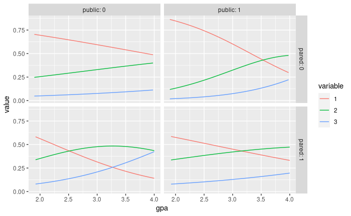

```r
ggplot(lnewdat, aes(x = gpa, y =value, colour = variable)) +
  geom_line() + facet_grid(pared ~ public, labeller="label_both")
```